# Minimal Detectable Effects (MDE)

Metaketa I

# Calculate arguments to generate correct ICCs

Generate base data for design declaration using observed control data

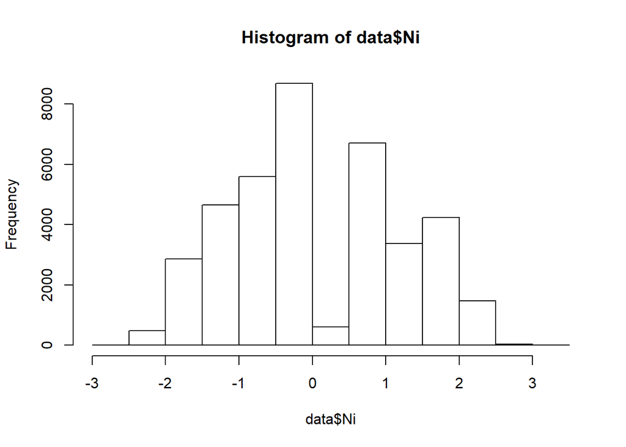

```r
mdat <- madat
mdat$Ni <- (mdat %>%
    group_by(ctry) %>%
    mutate(Ni = Q - P,
           Ni = Ni/sd(Ni, na.rm = TRUE )) %>%
    ungroup())$Ni
mdat <- mutate(mdat, Ni = ifelse(ctry == "mex", Q/sd(Q[ctry == "mex"], na.rm = TRUE), Ni))

# Control
data_1 <- filter(mdat, treat == 0) %>%
  select(ctry, fe, cl, m1, m3, ma_id, paired_block, ug2_councilor_dummy, N_good, ug2_contested, inv_wts, inv_wts2, Ni, m14, m17, m18, m20, m21, m22, m24, m26, m27)

data_2 <- mutate(data_1,cl = paste("doppel", cl), ma_id = paste("doppel", ma_id))

data <- bind_rows(data_1, data_2)

rm(mdat, data_1, data_2)

hist(data$Ni)
```

```r
# keep(data, estimates)
```

Get ICCs

```r
get_ICC <- function(df, dv = "m1"){
  df$dv  <- df[, dv]                         # dep var
  df$e   <- with(df, dv - ave(dv, fe, FUN = function(x) mean(x, na.rm = TRUE)))     # residual
  df$e2  <- with(df, e - ave(e, cl, FUN = function(x) mean(x, na.rm = TRUE)))
  1 - var(df$e2, na.rm = TRUE)/var(df$e, na.rm = TRUE)
}
```

Now choose a parameter that returns a reasonable ICC given what we know about the data

```r
ICC_given_gamma <- function(gamma, df = data, dv = "m1"){
  df$p_b <- ave(df[,dv], df$fe)           # Block level probability
  df <- fabricate(data = df,
                  cl = modify_level(u = gamma*rnorm(N), p_c = pnorm(qnorm(p_b) + u)),
                  ma_id  = modify_level(y = draw_binary(p_c)))
  get_ICC(df, dv = "y")
}
```

```r
kable(data.frame(
  m1_actual = get_ICC(data, dv = "m1"),
  m1_simuld = ICC_given_gamma(.72, df = data, dv = "m1"),
  m3_actual = get_ICC(data, dv = "m3"),
  m3_simuld = ICC_given_gamma(3.5, df = data, dv = "m3")
))
```

| m1_actual | m1_simuld | m3_actual | m3_simuld |
| --- | --- | --- | --- |
| 0.6097366 | 0.5335477 | 0.8922934 | 0.3955426 |

# Metaketa DeclareDesign Designer

We want to define a design with effects operating in terms of constant shifts in latent variable. Estimand and estimates however are defined in probabilities

We define a designer function which simply creates a design given some parameters of interest.

```r
metaketa_1_designer <-
  function(delta = 0, gamma = .8, df = data, depvar = "m1",
           exclude_councilors = FALSE, cov = "m14i+m17i+m18i+m20i+m21i+m22i+m24i+m26i+m27i",
           weights = TRUE, with_N = FALSE, good = TRUE, Q_good = FALSE, country = NULL,
           interactvar = NULL, treat1and2 = FALSE, contested_seats = TRUE,
           return_df = FALSE, skip_prep = TRUE){


    # Model
    df$Y_obs <- df[,depvar]   # The observed dependent variable
    df$p_b   <- ave(df$Y_obs, df$fe, FUN = function(x) mean(x, na.rm = TRUE))

    D <- declare_population(
      data = df,
      cl = modify_level(uc = gamma*rnorm(N), z_c = (qnorm(p_b) + uc)),
      ma_id = modify_level(ui = rnorm(N))
    )

    # Potential outcomes: fixed difference in latent variable
    Y <- declare_potential_outcomes(
      Y_Z_0 = 1*(ui < pnorm(z_c)),
      Y_Z_1 = 1*(ui < pnorm(z_c + delta*Ni))
    )

    # Assignment
    # uganda 2 assignment
    assign_ug2 <- function(data){
      df      <- data %>% group_by(fe) %>% mutate(block_n = length(unique(cl))) %>% ungroup()
      small   <- (df$block_n < 15)
      highlow <- block_and_cluster_ra(blocks = data$paired_block, clusters = data$fe, prob = .5)
      equal   <- block_and_cluster_ra(data$fe, data$cl, prob = .5)
      unequal <- block_and_cluster_ra(data$fe, data$cl, prob = .8)
      Z  <- small*equal + (1-small)*(highlow*unequal + (1-highlow)*(1-unequal))
      return(Z)
    }

    # Data: Assignment function
    assign <- function(data){
      # General assignment
      Z    <- block_and_cluster_ra(data$fe, data$cl, prob = .5)
      # Splice in Uganda Assignment
      rug2 <- data$ctry == "ug2"
      Z[rug2] <- assign_ug2(data[rug2,])
      # Handling for Mexico blocks with no variation in treatment assignment
      alwys_0 <- data$fe %in% paste0("mex.", c(22, 49, 81, 85, 92, 107))
      Z[alwys_0] <- 0
      data$Z <- Z
      return(data)
    }

    Z <- declare_assignment(handler = assign)  # Assign Z

    R <- declare_reveal(outcome_variables = Y, assignment_variables = Z)  # Reveal Y

    # Missingness
    # We assume data is missing at random and replicate the observed missing
    # data pattern in control in each simulation
    M <- declare_reveal(handler = fabricate, Y = ifelse(is.na(Y_obs), NA, Y))

    # Inquiry: Estimand is weighted effect
    # any subsetting eg for countries needs to be accounted for here
    Q <- declare_estimand(ATE = mean(sapply(unique(ctry), function (j){
      mean(Y_Z_1[ctry == j & N_good == good] -
           Y_Z_0[ctry == j & N_good == good],
           na.rm = TRUE)
    }
    )), label = "Country weighted ATE"
    )


    # A: Answer strategy
    mk1_estimator <- function(data){
      data$treat <- data$Z
      est <- estimates(dat = data,
                       exclude_councilors = exclude_councilors,
                       cov = cov, weights = weights, with_N = with_N,
                       good = good, Q_good = Q_good, depvar = "Y",
                       country = country, interactvar = interactvar,
                       treat1and2 = treat1and2, contested_seats = contested_seats,
                       return_df = FALSE, skip_prep = FALSE)
      statz <- as.data.frame(coef(summary(est)))[1,-3]
      names(statz) <- c("est", "se", "p")
      return(statz)
    }

    A <- declare_estimator(handler = tidy_estimator(mk1_estimator),
                           label = "Est with IPW, FE, Cl",
                           estimand = "ATE")


    # Design
    design <- D + Y + Z + Q + R + M + A

    return(design)

  }
```

# Summary design

Designs for Metaketa 1 given outcomes M1 and M3 and for good and bad news.

**Note for us**: in the next iteration these should all be estimands / estimates in a single design.

```r
mk1_m1g_design <- metaketa_1_designer(delta = 0, gamma = .73,
                                      df = data, depvar = "m1", good = TRUE)
mk1_m1b_design <- metaketa_1_designer(delta = 0, gamma = .73,
                                      df = data, depvar = "m1", good = FALSE)
mk1_m3g_design <- metaketa_1_designer(delta = 0, gamma = 4,
                                      df = data, depvar = "m3", good = TRUE)
mk1_m3b_design <- metaketa_1_designer(delta = 0, gamma = 4,
                                      df = data, depvar = "m3", good = FALSE)
```

Sample data:

```r
kable(head(draw_data(mk1_m1g_design)), digits = 2)
```

| ctry | fe | cl | m1 | m3 | ma_id | paired_block | ug2_councilor_dummy | N_good | ug2_contested | inv_wts | inv_wts2 | Ni | m14 | m17 | m18 | m20 | m21 | m22 | m24 | m26 | m27 | Y_obs | p_b | uc | z_c | ui | Y_Z_0 | Y_Z_1 | Z | … |
| --- | --- | --- | --- | --- | --- | --- | --- | --- | --- | --- | --- | --- | --- | --- | --- | --- | --- | --- | --- | --- | --- | --- | --- | --- | --- | --- | --- | --- | --- | --- |
| ben | ben.66 | ben.66.ADJRAKO | NA | NA | ben.66.ADJRAKO.134 | NA | NA | 1 | NA | NA | NA | 0.86 | 65 | 0 | 3 | 1 | 1 | NA | 0 | 1 | 3 | NA | 0.67 | -0.18 | 0.25 | 0.50 | 1 | 1 | 1 | … |
| ben | ben.66 | ben.66.ADJRAKO | 1 | 1 | ben.66.ADJRAKO.135 | NA | NA | 1 | NA | NA | NA | 0.86 | 40 | 6 | 4 | 1 | 1 | NA | 0 | 1 | 3 | 1 | 0.67 | -0.04 | 0.40 | 2.18 | 0 | 0 | 1 | … |
| ben | ben.66 | ben.66.ADJRAKO | 1 | 1 | ben.66.ADJRAKO.136 | NA | NA | 1 | NA | NA | NA | 0.86 | 19 | 16 | 3 | 0 | NA | 2 | 0 | 1 | 3 | 1 | 0.67 | 0.08 | 0.51 | 0.48 | 1 | 1 | 1 | … |
| ben | ben.66 | ben.66.ADJRAKO | NA | NA | ben.66.ADJRAKO.137 | NA | NA | 1 | NA | NA | NA | NA | 35 | 0 | 3 | 1 | 0 | 2 | 0 | 1 | 3 | NA | 0.67 | -0.04 | 0.39 | -0.74 | 1 | NA | 1 | … |
| ben | ben.66 | ben.66.ADJRAKO | 1 | 1 | ben.66.ADJRAKO.138 | NA | NA | 1 | NA | NA | NA | 0.86 | 28 | 2 | 3 | 1 | 1 | NA | 0 | 1 | 3 | 1 | 0.67 | -0.68 | -0.25 | 1.01 | 0 | 0 | 1 | … |
| ben | ben.66 | ben.66.ADJRAKO | NA | NA | ben.66.ADJRAKO.139 | NA | NA | 1 | NA | NA | NA | 0.86 | 25 | 0 | 3 | 1 | 1 | 2 | 0 | 1 | 3 | NA | 0.67 | -0.56 | -0.13 | -0.42 | 1 | 1 | 1 | … |

Sample estimates:

```r
kable(draw_estimates(mk1_m1g_design), digits = 3)
```

| estimator_label | est | se | p | estimand_label |
| --- | --- | --- | --- | --- |
| Est with IPW, FE, Cl | 0.008 | 0.016 | 0.626 | ATE |

```r
diagnosis <- diagnose_design(mk1_m1g_design, sims = sims, bootstrap_sims = 0)
```

```
## Error in is_list(sims): object 'sims' not found
```

[output not shown]

# MDE experiments

With a design in hand we can assess how it behaves differently given different modifications; we focus on different conjectured effect sizes.

To get a feel of how delta matters:

```r
kable(diagnose_design(redesign(mk1_m1g_design, delta = 1.5), bootstrap_sims = 0, sims = 2)[[2]])
```

| design_label | delta | estimand_label | estimator_label | bias | rmse | power | coverage | mean_estimate | sd_estimate | mean_se | type_s_rate | mean_estimand | n_sims |
| --- | --- | --- | --- | --- | --- | --- | --- | --- | --- | --- | --- | --- | --- |
| design_1 | 1.5 | ATE | Est with IPW, FE, Cl | NA | NA | NA | NA | NA | NA | NA | NA | 0.075356 | 2 |

```r
deltas = seq(0, 1.5, length = 7)
designs <- redesign(mk1_m1g_design, delta = deltas)
```

```r
diagnoses <- diagnose_design(designs, sims = 1, bootstrap_sims = 0)
```

[output not shown]

Bad news (one sim):

```r
designs3 <- redesign(mk1_m1b_design, delta = deltas)
diagnoses3 <- diagnose_design(designs3, sims = 1, bootstrap_sims = 0)
kable(cbind(delta = deltas, reshape_diagnosis(diagnoses3)), digits = 2)
```

| delta | Design Label | delta | Estimand Label | Estimator Label | Bias | RMSE | Power | Coverage | Mean Estimate | SD Estimate | Mean Se | Type S Rate | Mean Estimand | N Sims |
| --- | --- | --- | --- | --- | --- | --- | --- | --- | --- | --- | --- | --- | --- | --- |
| 0.00 | design_1 | deltas | ATE | Est with IPW, FE, Cl | NA | NA | NA | NA | NA | NA | NA | NA | 0.00 | 1 |
| 0.25 | design_2 | NA | ATE | Est with IPW, FE, Cl | NA | NA | NA | NA | NA | NA | NA | NA | -0.02 | 1 |
| 0.50 | design_3 | NA | ATE | Est with IPW, FE, Cl | NA | NA | NA | NA | NA | NA | NA | NA | -0.03 | 1 |
| 0.75 | design_4 | NA | ATE | Est with IPW, FE, Cl | NA | NA | NA | NA | NA | NA | NA | NA | -0.05 | 1 |
| 1.00 | design_5 | NA | ATE | Est with IPW, FE, Cl | NA | NA | NA | NA | NA | NA | NA | NA | -0.06 | 1 |
| 1.25 | design_6 | NA | ATE | Est with IPW, FE, Cl | NA | NA | NA | NA | NA | NA | NA | NA | -0.07 | 1 |
| 1.50 | design_7 | NA | ATE | Est with IPW, FE, Cl | NA | NA | NA | NA | NA | NA | NA | NA | -0.08 | 1 |

## Turnout design

Tables with a single sim to check estimand range

```r
designs2 <- redesign(mk1_m3g_design, delta = 4*deltas)
diagnoses2 <- diagnose_design(designs2, sims = 1, bootstrap_sims = 0)
kable(cbind(delta = 5*deltas, reshape_diagnosis(diagnoses2)), digits = 2)
```

| delta | Design Label | delta | Estimand Label | Estimator Label | Bias | RMSE | Power | Coverage | Mean Estimate | SD Estimate | Mean Se | Type S Rate | Mean Estimand | N Sims |
| --- | --- | --- | --- | --- | --- | --- | --- | --- | --- | --- | --- | --- | --- | --- |
| 0.00 | design_1 | 0 | ATE | Est with IPW, FE, Cl | NA | NA | NA | NA | NA | NA | NA | NA | 0.00 | 1 |
| 1.25 | design_2 | 1 | ATE | Est with IPW, FE, Cl | NA | NA | NA | NA | NA | NA | NA | NA | 0.02 | 1 |
| 2.50 | design_3 | 2 | ATE | Est with IPW, FE, Cl | NA | NA | NA | NA | NA | NA | NA | NA | 0.02 | 1 |
| 3.75 | design_4 | 3 | ATE | Est with IPW, FE, Cl | NA | NA | NA | NA | NA | NA | NA | NA | 0.04 | 1 |
| 5.00 | design_5 | 4 | ATE | Est with IPW, FE, Cl | NA | NA | NA | NA | NA | NA | NA | NA | 0.05 | 1 |
| 6.25 | design_6 | 5 | ATE | Est with IPW, FE, Cl | NA | NA | NA | NA | NA | NA | NA | NA | 0.05 | 1 |
| 7.50 | design_7 | 6 | ATE | Est with IPW, FE, Cl | NA | NA | NA | NA | NA | NA | NA | NA | 0.05 | 1 |

```r
designs4 <- redesign(mk1_m3b_design, delta = 4*deltas)
diagnoses4 <- diagnose_design(designs4, sims = 1, bootstrap_sims = 0)
kable(cbind(delta = 5*deltas, reshape_diagnosis(diagnoses4)), digits = 2)
```

| delta | Design Label | delta | Estimand Label | Estimator Label | Bias | RMSE | Power | Coverage | Mean Estimate | SD Estimate | Mean Se | Type S Rate | Mean Estimand | N Sims |
| --- | --- | --- | --- | --- | --- | --- | --- | --- | --- | --- | --- | --- | --- | --- |
| 0.00 | design_1 | 0 | ATE | Est with IPW, FE, Cl | NA | NA | NA | NA | NA | NA | NA | NA | 0.00 | 1 |
| 1.25 | design_2 | 1 | ATE | Est with IPW, FE, Cl | NA | NA | NA | NA | NA | NA | NA | NA | -0.02 | 1 |
| 2.50 | design_3 | 2 | ATE | Est with IPW, FE, Cl | NA | NA | NA | NA | NA | NA | NA | NA | -0.03 | 1 |
| 3.75 | design_4 | 3 | ATE | Est with IPW, FE, Cl | NA | NA | NA | NA | NA | NA | NA | NA | -0.05 | 1 |
| 5.00 | design_5 | 4 | ATE | Est with IPW, FE, Cl | NA | NA | NA | NA | NA | NA | NA | NA | -0.07 | 1 |
| 6.25 | design_6 | 5 | ATE | Est with IPW, FE, Cl | NA | NA | NA | NA | NA | NA | NA | NA | -0.08 | 1 |
| 7.50 | design_7 | 6 | ATE | Est with IPW, FE, Cl | NA | NA | NA | NA | NA | NA | NA | NA | -0.08 | 1 |

# All MDE plots

```r
dd <- function(design = mk1_m1g_design, scale=1){
  designs   <- redesign(design, delta = deltas*scale)
  diagnoses <- diagnose_design(designs, sims = sims, bootstrap_sims = 0)
  }

all_diagnoses <-
  list(m1g = dd(mk1_m1g_design ),
       m1b = dd(mk1_m1b_design ),
       m3g = dd(mk1_m3g_design, scale = 7),
       m3b = dd(mk1_m3b_design, scale = 4))

# save.image(file = "data/temp/diagnoses.Rdata")
save(all_diagnoses, file = "data/temp/mde_diagnoses.Rdata")
```

```r
# load(file = "data/temp/diagnoses.Rdata")
load(file = "data/temp/mde_diagnoses.Rdata")
```

```r
mde_plot <- function(diagnoses, main = ""){
  plot(abs(diagnoses[[2]][,12]), diagnoses[[2]][,6], ylim = c(0,1), xlim = c(0,.08),
       main = main, xlab = "ATE (Absolute value)", ylab = "power", type = "b")
  abline(a = .8, b = 0)
  }

pdf("figures/MDEs_w_cov_2.pdf")
  par(mfrow = c(2,2))
  mde_plot(all_diagnoses[[1]], main = "(a) Vote for incumbent, good news")
  mde_plot(all_diagnoses[[2]], main = "(b) Vote for incumbent, bad news")
  mde_plot(all_diagnoses[[3]], main = "(c) Turnout, good news")
  mde_plot(all_diagnoses[[4]], main = "(d) Turnout, bad news")
dev.off()
```

```r
all_diagnoses[[1]][[1]] %>% group_by(design_label) %>% mean(est< 0, na.rm = TRUE)
```

```
## [1] NA
```